# R Notebook

## ### Question 1.

#### a)

```r
bwgt <- read.csv("Q1.csv", header=T)
bwgt$Race <- as.factor(bwgt$Race)
bwgt$Smoke <- as.factor(bwgt$Smoke)

M0 <- lm(Bwtkg ~ 1, data=bwgt)
M1 <- lm(Bwtkg ~ Smoke + Lwtkg, data=bwgt)
M2 <- lm(Bwtkg ~ Smoke + Lwtkg + C(Race, sum), data=bwgt, x=T)


M0Design <- model.matrix(M0)
M1Design <- model.matrix(M1)
M2Design <- model.matrix(M2)

M0Design
```

```
   (Intercept)
1            1
2            1
3            1
4            1
5            1
6            1
7            1
8            1
9            1
10           1
11           1
12           1
13           1
14           1
15           1
16           1
17           1
18           1
19           1
20           1
attr(,"assign")
[1] 0
```

```r
M1Design
```

```
   (Intercept) Smoke1 Lwtkg
1            1      0  52.7
2            1      0  79.5
3            1      0  54.5
4            1      1  59.1
5            1      1  86.4
6            1      1  56.4
7            1      1  77.3
8            1      1  50.0
9            1      1  49.5
10           1      1  64.5
11           1      1  55.0
12           1      1  55.9
13           1      1  43.2
14           1      1  63.6
15           1      0  71.8
16           1      1  76.4
17           1      0  43.6
18           1      0  56.8
19           1      0  55.9
20           1      1  42.7
attr(,"assign")
[1] 0 1 2
attr(,"contrasts")
attr(,"contrasts")$Smoke
[1] "contr.treatment"
```

```r
#options(contrasts = rep ("contr.treatment", 2))
#constraintBwgt <- bwgt
#attr (bwgt$Race, "contrasts") <- contr.poly

M2Design
```

```
   (Intercept) Smoke1 Lwtkg C(Race, sum)1 C(Race, sum)2
1            1      0  52.7             1             0
2            1      0  79.5             1             0
3            1      0  54.5             1             0
4            1      1  59.1             1             0
5            1      1  86.4             1             0
6            1      1  56.4             1             0
7            1      1  77.3             1             0
8            1      1  50.0             1             0
9            1      1  49.5             1             0
10           1      1  64.5             1             0
11           1      1  55.0             1             0
12           1      1  55.9             1             0
13           1      1  43.2             1             0
14           1      1  63.6             1             0
15           1      0  71.8             0             1
16           1      1  76.4             0             1
17           1      0  43.6            -1            -1
18           1      0  56.8            -1            -1
19           1      0  55.9            -1            -1
20           1      1  42.7            -1            -1
attr(,"assign")
[1] 0 1 2 3 3
attr(,"contrasts")
attr(,"contrasts")$Smoke
[1] "contr.treatment"

attr(,"contrasts")$`C(Race, sum)`
[1] "contr.sum"
```

#### b)

```r
M0 <- lm(Bwtkg ~ 1, data=bwgt, x=T)
M1 <- lm(Bwtkg ~ C(Smoke, sum) + Lwtkg, data=bwgt, x=T)
M2 <- lm(Bwtkg ~ C(Smoke, sum) + Lwtkg + C(Race, sum), data=bwgt, x=T)

summary(M0)
```

```
Call:
lm(formula = Bwtkg ~ 1, data = bwgt, x = T)

Residuals:
    Min      1Q  Median      3Q     Max
-1.0275 -0.6300 -0.1025  0.5225  1.5025

Coefficients:
            Estimate Std. Error t value Pr(>|t|)
(Intercept)    3.087      0.160    19.3 6.09e-14 ***
---
Signif. codes:  0 ‘***’ 0.001 ‘**’ 0.01 ‘*’ 0.05 ‘.’ 0.1 ‘ ’ 1

Residual standard error: 0.7155 on 19 degrees of freedom
```

This is the basic model with just the population mean compared with the Bwtg response variable. We do not have any predictors assigned to this model.

```r
summary(M1)
```

```
Call:
lm(formula = Bwtkg ~ C(Smoke, sum) + Lwtkg, data = bwgt, x = T)

Residuals:
     Min       1Q   Median       3Q      Max
-1.29920 -0.48090 -0.03944  0.33924  1.25360

Coefficients:
               Estimate Std. Error t value Pr(>|t|)
(Intercept)     2.82183    0.79405   3.554  0.00244 **
C(Smoke, sum)1  0.22157    0.16829   1.317  0.20546
Lwtkg           0.00556    0.01301   0.427  0.67459
---
Signif. codes:  0 ‘***’ 0.001 ‘**’ 0.01 ‘*’ 0.05 ‘.’ 0.1 ‘ ’ 1

Residual standard error: 0.7177 on 17 degrees of freedom
Multiple R-squared:  0.09982,   Adjusted R-squared:  -0.006084
F-statistic: 0.9426 on 2 and 17 DF,  p-value: 0.4091
```

p values show that Smoking and Lwtkg are not very significant predictors. R^2 is quite low, and F-statistic p value also shows low significance

```r
summary(M2)
```

```
Call:
lm(formula = Bwtkg ~ C(Smoke, sum) + Lwtkg + C(Race, sum), data = bwgt,
    x = T)

Residuals:
    Min      1Q  Median      3Q     Max
-0.7738 -0.4386 -0.0772  0.4860  1.0121

Coefficients:
                Estimate Std. Error t value Pr(>|t|)
(Intercept)     3.394806   0.848531   4.001  0.00116 **
C(Smoke, sum)1  0.425789   0.166893   2.551  0.02214 *
Lwtkg          -0.006543   0.013446  -0.487  0.63356
C(Race, sum)1   0.464641   0.232271   2.000  0.06389 .
C(Race, sum)2   0.210039   0.362143   0.580  0.57053
---
Signif. codes:  0 ‘***’ 0.001 ‘**’ 0.01 ‘*’ 0.05 ‘.’ 0.1 ‘ ’ 1

Residual standard error: 0.6301 on 15 degrees of freedom
Multiple R-squared:  0.3877,    Adjusted R-squared:  0.2244
F-statistic: 2.374 on 4 and 15 DF,  p-value: 0.09867
```

#### c)

##### i.

```r
M2.x <- matrix(M2$x, nrow=20)
M2.y <- matrix(bwgt$Bwtkg, nrow=20, ncol=1)

M2.xtx <- t(M2.x) %*% M2.x
M2.inv.xtx <- solve(M2.xtx)

M2.beta <- M2.inv.xtx%*%t(M2.x)%*%M2.y
M2.beta
```

```
             [,1]
[1,]  3.394806155
[2,]  0.425788904
[3,] -0.006543122
[4,]  0.464641094
[5,]  0.210039190
```

##### ii.

```r
M2.Hat <- M2.x %*% M2.inv.xtx%*%t(M2.x)

#P = I - H
M2.Proj <- diag(nrow=nrow(M2.Hat)) - M2.Hat

# residuals = Py
M2.ehat <- M2.Proj%*%M2.y

# Residual standard error
M2.RSE <- sqrt(sum(M2.ehat^2) / df.residual(M2))
M2.RSE
```

```
[1] 0.6301172
```

##### iii.

```r
# MSE = yT*ehat / (n-p)
M2.varhat <- (t(M2.y)%*%M2.ehat)/(length(M2.y)-length(bwgt))
M2.varhat
```

```
          [,1]
[1,] 0.3722322
```

```r
M2.RSE * sqrt(diag(M2.inv.xtx))
```

```
[1] 0.84853074 0.16689290 0.01344612 0.23227121 0.36214257
```

#### d)

Uncorrected values

##### i.

```r
M2.SSRu <- t(M2.yhat) %*% M2.yhat
M2.SSRu
```

```
         [,1]
[1,] 194.4242
```

```r
M2.SSE <- t(M2.ehat) %*% M2.ehat
M2.SSE
```

```
         [,1]
[1,] 5.955715
```

```r
M2.SSTu <- t(M2.y) %*% M2.y
M2.SSTu
```

```
         [,1]
[1,] 200.3799
```

```r
# Are these equal?
all.equal(M2.SSTu, M2.SSRu + M2.SSE)
```

```
[1] TRUE
```

##### ii.

Corrected values

```r
X1 <- matrix(rep(1, NROW(M2.Hat)))
H1 <- X1 %*% solve(t(X1)%*%X1) %*% t(X1)
M2.SSR <- t(M2.y) %*% (M2.Hat - H1) %*% M2.y
M2.SSR
```

```
        [,1]
[1,] 3.77106
```

```r
M2.SST <- M2.SSTu - t(M2.y) %*% H1 %*% M2.y
M2.SST
```

```
         [,1]
[1,] 9.726775
```

```r
# Are these equal?
all.equal(M2.SST, M2.SSR + M2.SSE)
```

```
[1] TRUE
```

#### e)

```r
anova(M2)
```

```
Analysis of Variance Table

Response: Bwtkg
              Df Sum Sq Mean Sq F value  Pr(>F)
C(Smoke, sum)  1 0.8769 0.87692  2.2086 0.15796
Lwtkg          1 0.0940 0.09400  0.2367 0.63360
C(Race, sum)   2 2.8001 1.40007  3.5262 0.05556 .
Residuals     15 5.9557 0.39705
---
Signif. codes:  0 ‘***’ 0.001 ‘**’ 0.01 ‘*’ 0.05 ‘.’ 0.1 ‘ ’ 1
```

First off, R makes it easy to see that only Race is a significant factor (at the 90% level) after considering Smoking and Lwtkg.

This means we reject $H_0$: All group means are equal.

However, in the following table:

```r
summary(M2)$coefficients
```

```
                   Estimate Std. Error    t value   Pr(>|t|)
(Intercept)     3.394806155 0.84853074  4.0008051 0.00115742
C(Smoke, sum)1  0.425788904 0.16689290  2.5512703 0.02214214
Lwtkg          -0.006543122 0.01344612 -0.4866179 0.63356254
C(Race, sum)1   0.464641094 0.23227121  2.0004248 0.06389472
C(Race, sum)2   0.210039190 0.36214257  0.5799903 0.57053127
```

we see that smoke is considered a significant factor. This might be an issue with the order of the F-tests.

#### f)

##### i.

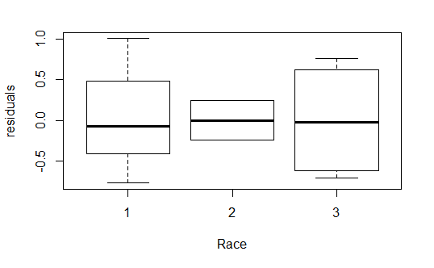

```r
plot(bwgt$Race, M2$residuals, xlab='Race', ylab='residuals')
```

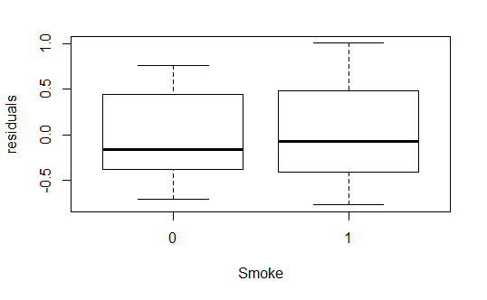

```r
plot(bwgt$Smoke, M2$residuals, xlab='Smoke', ylab='residuals')
```

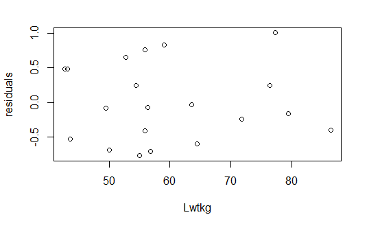

```r
plot(bwgt$Lwtkg, M2$residuals, xlab='Lwtkg', ylab='residuals')
```

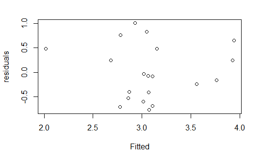

```r
plot(M2$fitted.values, M2$residuals, xlab='Fitted', ylab='residuals')
```

Roughly same mean and equal variance in Race, Smoke.

##### ii.

$H_0$: $\beta_1 = 0$ $H_1$: $\beta_1 != 0$